# Top 1000 Twitch Streamers

Zeyu Li

117490770

CMSC 320

Final Tutorial Project

## Introduction

Streamers are individuals or groups who broadcast their video gameplay or other content online through platforms such as Twitch, YouTube, or Mixer. They often interact with their audience through a live chat feature, and may also include commentary or commentary on the game they are playing. Many streamers also play music or engage in creative activities such as art or cooking on their channels. Some streamers make a living from their streams through advertising revenue, donations from their viewers, or subscriptions to their channels. Many popular streamers have large followings and can influence the success of a game or other product through their promotion. Streamers may also participate in eSports tournaments and other events, and may be sponsored by game developers or companies in the gaming industry. Overall, streaming has become a significant part of the gaming industry and has opened up new opportunities for content creators to connect with and entertain their audiences.

In this project, we will focus on and analyze the dataset of the top 1000 twitch streamers in 2020, and find out what can we conclude from the dataset about this rising entertainment industry.

[figure not shown]

## Outline

• Import Data

• Overall Analysis

• Individual Streamer Information

• Conclusion

## Import Data

```python
# Import required libraries and packages
import warnings
warnings.simplefilter(action='ignore', category=FutureWarning)
import numpy as np
import pandas as pd
import matplotlib.pyplot as plt
import seaborn as sns
import statsmodels.api as sm
from statsmodels.formula.api import ols
```

```python
# Import the csv dataset
streamer=pd.read_csv('twitchdata-update.csv')
streamer
```

|  | Channel | Watch time(Minutes) | Stream time(minutes) | Peak viewers | Average viewers | Followers | Followers gained | Views gained | Partnered | Mature | Language |
| --- | --- | --- | --- | --- | --- | --- | --- | --- | --- | --- | --- |
| 0 | xQcOW | 6196161750 | 215250 | 222720 | 27716 | 3246298 | 1734810 | 93036735 | True | False | English |
| 1 | summit1g | 6091677300 | 211845 | 310998 | 25610 | 5310163 | 1370184 | 89705964 | True | False | English |
| 2 | Gaules | 5644590915 | 515280 | 387315 | 10976 | 1767635 | 1023779 | 102611607 | True | True | Portuguese |
| 3 | ESL_CSGO | 3970318140 | 517740 | 300575 | 7714 | 3944850 | 703986 | 106546942 | True | False | English |
| 4 | Tfue | 3671000070 | 123660 | 285644 | 29602 | 8938903 | 2068424 | 78998587 | True | False | English |
| ... | ... | ... | ... | ... | ... | ... | ... | ... | ... | ... | ... |
| 995 | LITkillah | 122524635 | 13560 | 21359 | 9104 | 601927 | 562691 | 2162107 | True | False | Spanish |
| 996 | 빅헤드 (bighead033) | 122523705 | 153000 | 3940 | 793 | 213212 | 52289 | 4399897 | True | False | Korean |
| 997 | 마스카 (newmasca) | 122452320 | 217410 | 6431 | 567 | 109068 | -4942 | 3417970 | True | False | Korean |
| 998 | AndyMilonakis | 122311065 | 104745 | 10543 | 1153 | 547446 | 109111 | 3926918 | True | False | English |
| 999 | Remx | 122192850 | 99180 | 13788 | 1205 | 178553 | 59432 | 2049420 | True | False | French |

1000 rows × 11 columns

The above dataset was downloaded from website kaggle: https://www.kaggle.com/datasets/aayushmishra1512/twitchdata?resource=download

## Overall Analysis

The following are the languages mainly used by all 1000 streamers in the database：

```python
# Check what types of language are in the dataset
streamer['Language'].unique()
```

```
array(['English', 'Portuguese', 'Spanish', 'German', 'Korean', 'French',
       'Russian', 'Japanese', 'Chinese', 'Czech', 'Turkish', 'Italian',
       'Polish', 'Thai', 'Arabic', 'Slovak', 'Other', 'Hungarian',
       'Greek', 'Finnish', 'Swedish'], dtype=object)
```

```python
# Group the dataset by language
streamer_1 = streamer
streamer_1['count'] = 1
Language = streamer_1.groupby(by = ['Language']).sum()
Language
```

| Language | Watch time(Minutes) | Stream time(minutes) | Peak viewers | Average viewers | Followers | Followers gained | Views gained | Partnered | Mature | count |
| --- | --- | --- | --- | --- | --- | --- | --- | --- | --- | --- |
| Arabic | 1195252140 | 249675 | 291407 | 28411 | 4082688 | 2399691 | 13898403 | 5 | 0 | 5 |
| Chinese | 10168679430 | 4516920 | 393131 | 102744 | 6051436 | 846298 | 318848589 | 30 | 10 | 30 |
| Czech | 1722566070 | 844695 | 59511 | 10966 | 1484249 | 556830 | 56108241 | 6 | 3 | 6 |
| English | 228881005575 | 60373935 | 20195264 | 2479715 | 342257538 | 98597745 | 6080449579 | 476 | 136 | 485 |
| Finnish | 215726910 | 209625 | 9676 | 1027 | 255595 | 29422 | 10284627 | 1 | 1 | 1 |
| French | 24952911375 | 8699565 | 2235117 | 231431 | 29022481 | 11972870 | 671849256 | 65 | 15 | 66 |
| German | 19304087745 | 5701800 | 1532462 | 209631 | 23489011 | 8437654 | 410981549 | 48 | 14 | 49 |
| Greek | 230552955 | 123345 | 6289 | 1961 | 82289 | 51159 | 4148542 | 1 | 0 | 1 |
| Hungarian | 464458725 | 223650 | 49560 | 4281 | 695713 | 183510 | 16439999 | 2 | 1 | 2 |
| Italian | 4285684125 | 2093235 | 296227 | 37494 | 5592352 | 3332585 | 177798995 | 17 | 1 | 17 |
| Japanese | 4186577100 | 1430685 | 220135 | 47626 | 1601458 | 594828 | 87158756 | 10 | 0 | 10 |
| Korean | 27794413845 | 9231165 | 1434744 | 301369 | 20187388 | 6671544 | 729666947 | 76 | 1 | 77 |
| Other | 298828170 | 232620 | 11533 | 1149 | 30986 | 29434 | 60922719 | 0 | 0 | 1 |
| Polish | 4301828310 | 1549140 | 239617 | 34863 | 4765087 | 1420316 | 127211999 | 12 | 1 | 12 |
| Portuguese | 27601786080 | 9668310 | 2346272 | 231857 | 33907964 | 15077100 | 662989908 | 60 | 17 | 61 |
| Russian | 27840609765 | 6755730 | 3277461 | 487973 | 25140056 | 10127899 | 1221159349 | 67 | 9 | 74 |
| Slovak | 304222200 | 148335 | 9248 | 2072 | 252184 | 37681 | 8585834 | 1 | 0 | 1 |
| Spanish | 25581245295 | 4945800 | 3616715 | 438579 | 53018656 | 38785709 | 667468192 | 67 | 11 | 68 |
| Swedish | 131621775 | 128085 | 2727 | 1027 | 96691 | 25277 | 5787660 | 1 | 1 | 1 |
| Thai | 2702248245 | 1819575 | 178141 | 22125 | 2223654 | 636201 | 97354217 | 11 | 3 | 11 |
| Turkish | 6263624295 | 1569270 | 659814 | 104739 | 15816592 | 5704781 | 239052252 | 22 | 6 | 22 |

```python
# Find the highest average values groupby language
ave = streamer_1.groupby(by = ['Language']).mean()
ave.sort_values(by = ['Watch time(Minutes)'], ascending = False).head(1)
```

| Language | Watch time(Minutes) | Stream time(minutes) | Peak viewers | Average viewers | Followers | Followers gained | Views gained | Partnered | Mature | count |
| --- | --- | --- | --- | --- | --- | --- | --- | --- | --- | --- |
| English | 4.719196e+08 | 124482.340206 | 41639.719588 | 5112.814433 | 705685.645361 | 203294.319588 | 1.253701e+07 | 0.981443 | 0.280412 | 1.0 |

```python
ave.sort_values(by = ['Stream time(minutes)'], ascending = False).head(1)
```

| Language | Watch time(Minutes) | Stream time(minutes) | Peak viewers | Average viewers | Followers | Followers gained | Views gained | Partnered | Mature | count |
| --- | --- | --- | --- | --- | --- | --- | --- | --- | --- | --- |
| Other | 298828170.0 | 232620.0 | 11533.0 | 1149.0 | 30986.0 | 29434.0 | 60922719.0 | 0.0 | 0.0 | 1.0 |

```python
ave.sort_values(by = ['Peak viewers'], ascending = False).head(1)
```

| Language | Watch time(Minutes) | Stream time(minutes) | Peak viewers | Average viewers | Followers | Followers gained | Views gained | Partnered | Mature | count |
| --- | --- | --- | --- | --- | --- | --- | --- | --- | --- | --- |
| Arabic | 239050428.0 | 49935.0 | 58281.4 | 5682.2 | 816537.6 | 479938.2 | 2779680.6 | 1.0 | 0.0 | 1.0 |

```python
ave.sort_values(by = ['Average viewers'], ascending = False).head(1)
```

| Language | Watch time(Minutes) | Stream time(minutes) | Peak viewers | Average viewers | Followers | Followers gained | Views gained | Partnered | Mature | count |
| --- | --- | --- | --- | --- | --- | --- | --- | --- | --- | --- |
| Russian | 3.762245e+08 | 91293.648649 | 44290.013514 | 6594.22973 | 339730.486486 | 136863.5 | 1.650215e+07 | 0.905405 | 0.121622 | 1.0 |

```python
ave.sort_values(by = ['Followers'], ascending = False).head(1)
```

| Language | Watch time(Minutes) | Stream time(minutes) | Peak viewers | Average viewers | Followers | Followers gained | Views gained | Partnered | Mature | count |
| --- | --- | --- | --- | --- | --- | --- | --- | --- | --- | --- |
| Arabic | 239050428.0 | 49935.0 | 58281.4 | 5682.2 | 816537.6 | 479938.2 | 2779680.6 | 1.0 | 0.0 | 1.0 |

```python
ave.sort_values(by = ['Followers gained'], ascending = False).head(1)
```

| Language | Watch time(Minutes) | Stream time(minutes) | Peak viewers | Average viewers | Followers | Followers gained | Views gained | Partnered | Mature | count |
| --- | --- | --- | --- | --- | --- | --- | --- | --- | --- | --- |
| Spanish | 3.761948e+08 | 72732.352941 | 53186.985294 | 6449.691176 | 779686.117647 | 570378.073529 | 9.815709e+06 | 0.985294 | 0.161765 | 1.0 |

```python
ave.sort_values(by = ['Views gained'], ascending = False).head(1)
```

| Language | Watch time(Minutes) | Stream time(minutes) | Peak viewers | Average viewers | Followers | Followers gained | Views gained | Partnered | Mature | count |
| --- | --- | --- | --- | --- | --- | --- | --- | --- | --- | --- |
| Other | 298828170.0 | 232620.0 | 11533.0 | 1149.0 | 30986.0 | 29434.0 | 60922719.0 | 0.0 | 0.0 | 1.0 |

```python
ave.sort_values(by = ['Partnered'], ascending = False).head(14)
```

| Language | Watch time(Minutes) | Stream time(minutes) | Peak viewers | Average viewers | Followers | Followers gained | Views gained | Partnered | Mature | count |
| --- | --- | --- | --- | --- | --- | --- | --- | --- | --- | --- |
| Arabic | 2.390504e+08 | 49935.000000 | 58281.400000 | 5682.200000 | 816537.600000 | 479938.200000 | 2.779681e+06 | 1.000000 | 0.000000 | 1.0 |
| Hungarian | 2.322294e+08 | 111825.000000 | 24780.000000 | 2140.500000 | 347856.500000 | 91755.000000 | 8.220000e+06 | 1.000000 | 0.500000 | 1.0 |
| Thai | 2.456589e+08 | 165415.909091 | 16194.636364 | 2011.363636 | 202150.363636 | 57836.454545 | 8.850383e+06 | 1.000000 | 0.272727 | 1.0 |
| Swedish | 1.316218e+08 | 128085.000000 | 2727.000000 | 1027.000000 | 96691.000000 | 25277.000000 | 5.787660e+06 | 1.000000 | 1.000000 | 1.0 |
| Slovak | 3.042222e+08 | 148335.000000 | 9248.000000 | 2072.000000 | 252184.000000 | 37681.000000 | 8.585834e+06 | 1.000000 | 0.000000 | 1.0 |
| Polish | 3.584857e+08 | 129095.000000 | 19968.083333 | 2905.250000 | 397090.583333 | 118359.666667 | 1.060100e+07 | 1.000000 | 0.083333 | 1.0 |
| Chinese | 3.389560e+08 | 150564.000000 | 13104.366667 | 3424.800000 | 201714.533333 | 28209.933333 | 1.062829e+07 | 1.000000 | 0.333333 | 1.0 |
| Italian | 2.520991e+08 | 123131.470588 | 17425.117647 | 2205.529412 | 328961.882353 | 196034.411765 | 1.045876e+07 | 1.000000 | 0.058824 | 1.0 |
| Japanese | 4.186577e+08 | 143068.500000 | 22013.500000 | 4762.600000 | 160145.800000 | 59482.800000 | 8.715876e+06 | 1.000000 | 0.000000 | 1.0 |
| Greek | 2.305530e+08 | 123345.000000 | 6289.000000 | 1961.000000 | 82289.000000 | 51159.000000 | 4.148542e+06 | 1.000000 | 0.000000 | 1.0 |
| Finnish | 2.157269e+08 | 209625.000000 | 9676.000000 | 1027.000000 | 255595.000000 | 29422.000000 | 1.028463e+07 | 1.000000 | 1.000000 | 1.0 |
| Czech | 2.870943e+08 | 140782.500000 | 9918.500000 | 1827.666667 | 247374.833333 | 92805.000000 | 9.351374e+06 | 1.000000 | 0.500000 | 1.0 |
| Turkish | 2.847102e+08 | 71330.454545 | 29991.545455 | 4760.863636 | 718936.000000 | 259308.227273 | 1.086601e+07 | 1.000000 | 0.272727 | 1.0 |
| Korean | 3.609664e+08 | 119885.259740 | 18633.038961 | 3913.883117 | 262173.870130 | 86643.428571 | 9.476194e+06 | 0.987013 | 0.012987 | 1.0 |

```python
ave.sort_values(by = ['Mature'], ascending = False).head(3)
```

| Language | Watch time(Minutes) | Stream time(minutes) | Peak viewers | Average viewers | Followers | Followers gained | Views gained | Partnered | Mature | count |
| --- | --- | --- | --- | --- | --- | --- | --- | --- | --- | --- |
| Finnish | 215726910.0 | 209625.0 | 9676.0 | 1027.000000 | 255595.000000 | 29422.0 | 10284627.0 | 1.0 | 1.0 | 1.0 |
| Swedish | 131621775.0 | 128085.0 | 2727.0 | 1027.000000 | 96691.000000 | 25277.0 | 5787660.0 | 1.0 | 1.0 | 1.0 |
| Czech | 287094345.0 | 140782.5 | 9918.5 | 1827.666667 | 247374.833333 | 92805.0 | 9351373.5 | 1.0 | 0.5 | 1.0 |

Among all of those columns above, we could conclude that English streamers have the longest average watch time, other language streamers have the longest average streaming time, Arabic streamers have the highest average peak viewers count, Russian streamers have the highest average viewers count, Arabic streamers have the highest average followers count, Spanish streamers have the highest followers gained count, other language streamers have the highest views gained count, and there are 13 different language streamers share the highest partnered rate which is 100%, and Finnish, Swedish streamers share the highest mature content rate, which is 100%. I think the latter two highest rates were shared by more than one streamer language because there are only one or two streamers using those languages in the top 1000.

So next we will find out what the percentage of each language used among them.

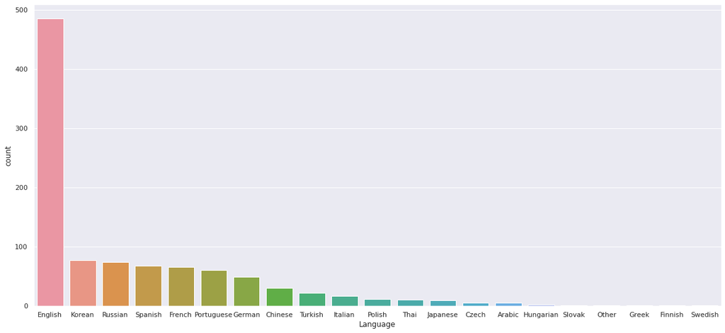

```python
# Generate countplot and group by descending order
sns.set(rc = {'figure.figsize':(20,9)})
sns.countplot(x = 'Language',
              data = streamer,
             order = streamer['Language'].value_counts().index);
```

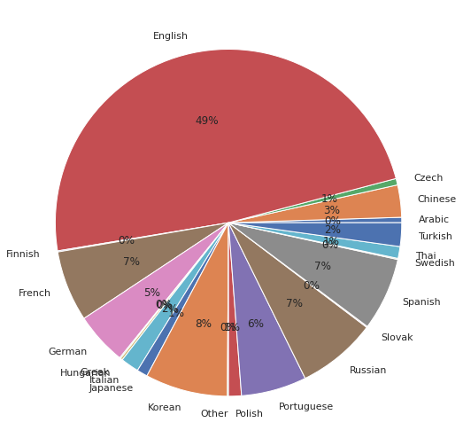

```python
# Plot pie chart to see the percentage
plt.pie(Language['count'],labels = Language.index, autopct = '%.0f%%');
```

From the generated histogram and pie chart above, we can preliminarily see that the main language audience of the top 1,000 streamers on the Twitch platform is English-speaking viewers, accounting for nearly 50% of the total 1000. This percentage is followed by Korean(8%), Russian(7%), Spanish(7%) and French(7%).

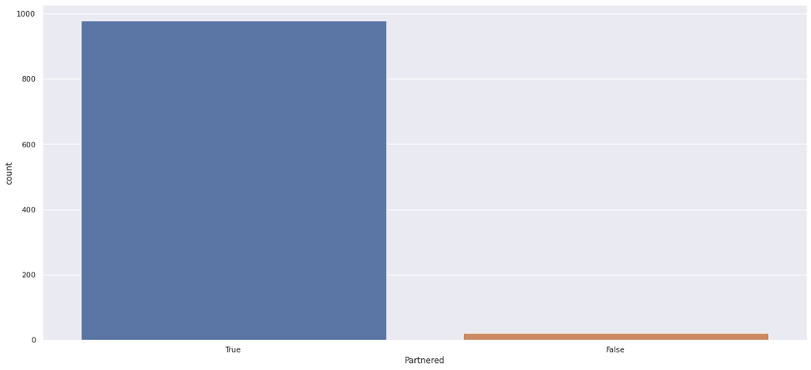

```python
sns.countplot(x = 'Partnered',
              data = streamer,
            order = streamer['Partnered'].value_counts().index);
```

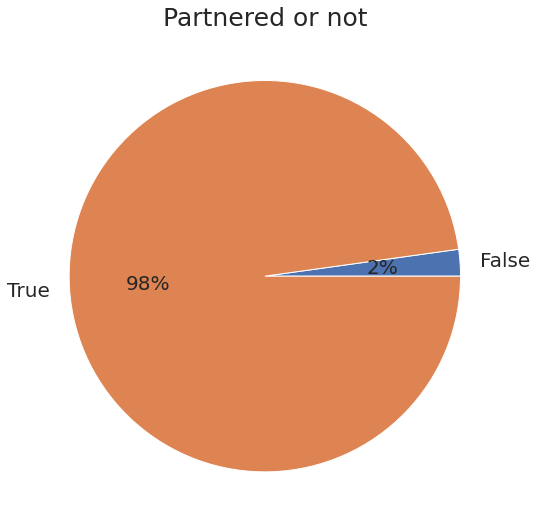

```python
# Plot pie chart to see the percentage
Partner = streamer
Partner['count'] = 1
Partner = Partner.groupby(by = ['Partnered']).sum()
plt.pie(Partner['count'],labels = Partner.index, autopct = '%.0f%%',textprops = {'fontsize': 20});
plt.title("Partnered or not", fontsize = "25");
```

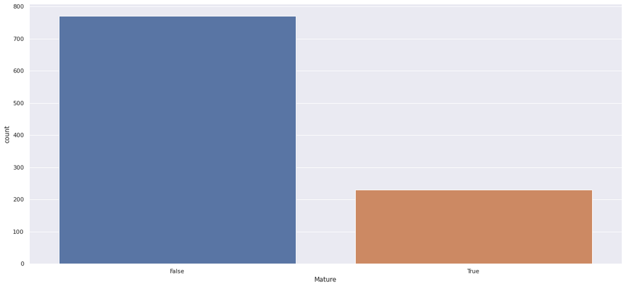

```python
sns.countplot(x = 'Mature',
              data = streamer,
            order = streamer['Mature'].value_counts().index);
```

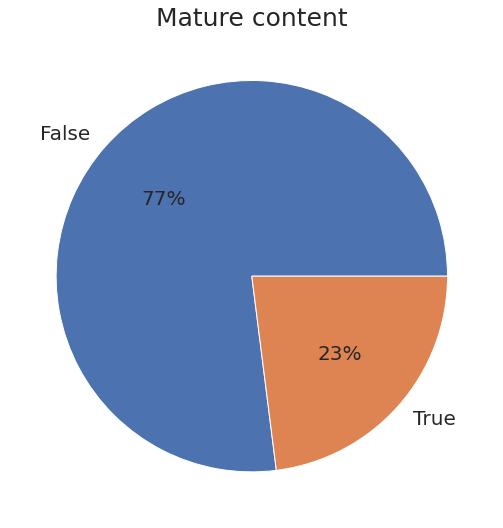

```python
# Plot pie chart to see the percentage
mature = streamer
mature['count'] = 1
mature = mature.groupby(by = ['Mature']).sum()
plt.pie(mature['count'],labels = mature.index, autopct = '%.0f%%',textprops = {'fontsize': 20});
plt.title("Mature content", fontsize = "25");
```

According to the graph above, we can conclude that among all 1000 top Twitch Streamers, most of them (98%) were partnered with someone and only a few were not. Also, there is a fair amount of them (23%) were streaming 18+ content on stream.

## Individual Streamer Information Analysis

Now we will focus on individual Streamer and their related data:

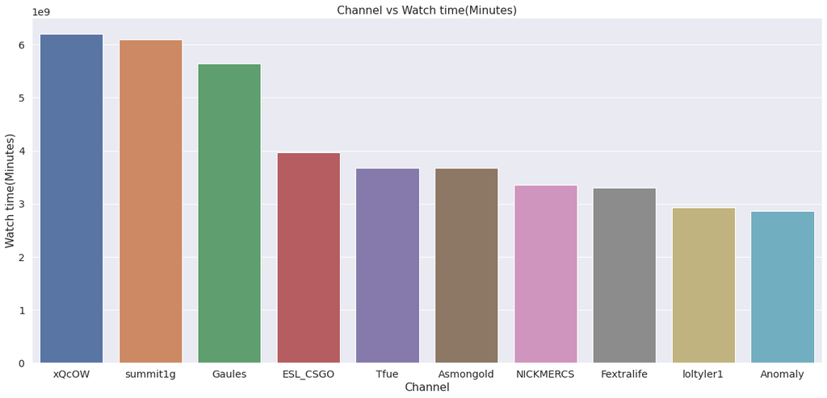

```python
# Show the top 10 channels for watch time
sns.set(font_scale = 1.3)
sns.barplot( data = streamer.head(10),
            x = 'Channel',
            y = 'Watch time(Minutes)',
           ).set(title = 'Channel vs Watch time(Minutes)');
```

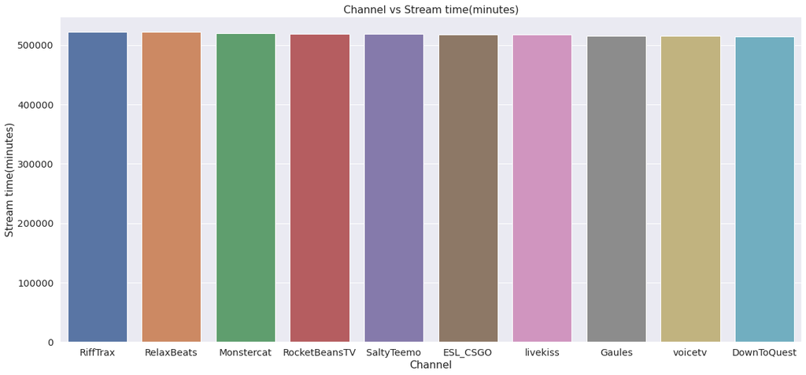

```python
# Show the top 10 channels for stream time
streamer_1 = streamer.sort_values(by = ['Stream time(minutes)'], ascending = False)
sns.barplot( data = streamer_1.head(10),
            x = 'Channel',
            y = 'Stream time(minutes)',
           ).set(title = 'Channel vs Stream time(minutes)');
```

From this plot, we can see that it doesn't show too much difference among the top 10 longest streaming time, and all of them surpass 500000 minutues.

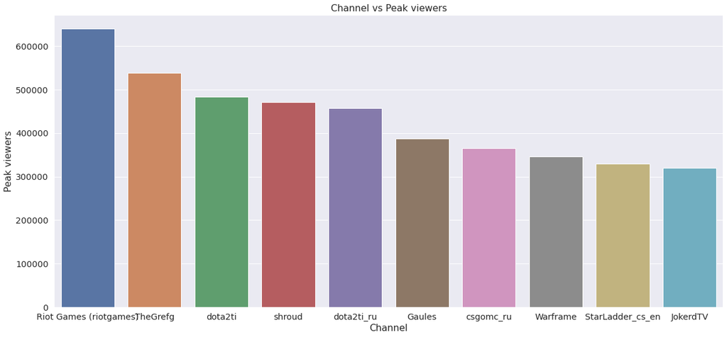

```python
# Show the top 10 channels for peak viewers
streamer_1 = streamer.sort_values(by = ['Peak viewers'], ascending = False)
sns.barplot( data = streamer_1.head(10),
            x = 'Channel',
            y = 'Peak viewers',
           ).set(title = 'Channel vs Peak viewers');
```

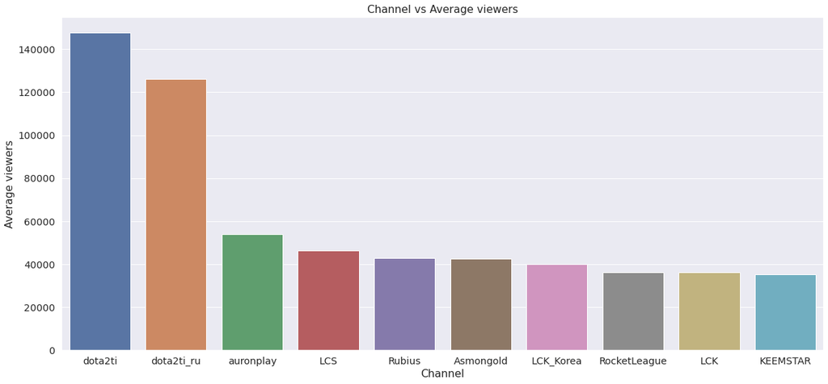

```python
# Show the top 10 channels for average viewers
streamer_1 = streamer.sort_values(by = ['Average viewers'], ascending = False)
sns.barplot( data = streamer_1.head(10),
            x = 'Channel',
            y = 'Average viewers',
           ).set(title = 'Channel vs Average viewers');
```

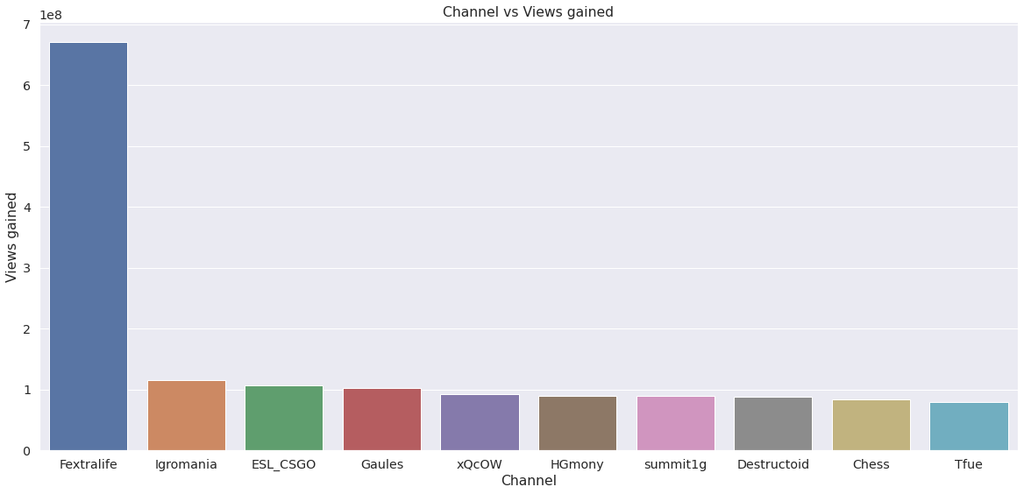

```python
# Show the top 10 channels for views gained
streamer_1 = streamer.sort_values(by = ['Views gained'], ascending = False)
sns.barplot( data = streamer_1.head(10),
            x = 'Channel',
            y = 'Views gained',
           ).set(title = 'Channel vs Views gained');
```

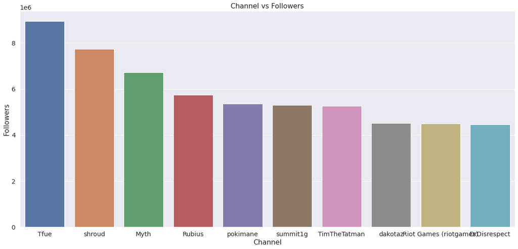

```python
# Show the top 10 channels for followers
streamer_1 = streamer.sort_values(by = ['Followers'], ascending = False)
sns.barplot( data = streamer_1.head(10),
            x = 'Channel',
            y = 'Followers',
           ).set(title = 'Channel vs Followers');
```

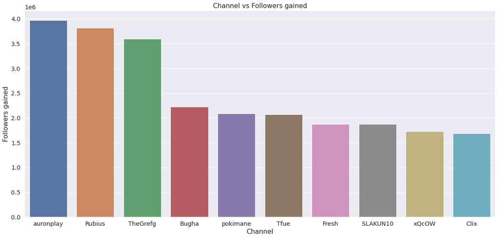

```python
# Show the top 10 channels for followers gained
streamer_1 = streamer.sort_values(by = ['Followers gained'], ascending = False)
sns.barplot( data = streamer_1.head(10),
            x = 'Channel',
            y = 'Followers gained',
           ).set(title = 'Channel vs Followers gained');
```

According to the graph generated above about Channel versus each quantitative value, we can see that the top 10 streamers of each graph are not always the same group. However, we still need further analysis to determine whether columns are depend on each other.

Next, we will randomly try some columns and plot them to see what kind of relation we can find.

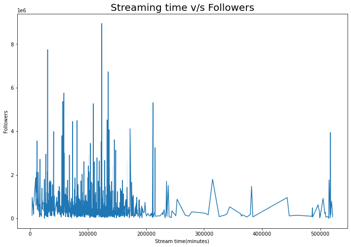

```python
# Comparing streaming time v/s Followers
plt.figure(figsize=(12,8))
sns.lineplot(streamer['Stream time(minutes)'], streamer['Followers']);
plt.title('Streaming time v/s Followers', fontsize = 20);
plt.show();
```

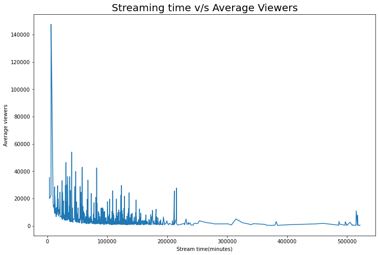

```python
# Comparing streaming time v/s Average viewers
plt.figure(figsize=(12,8)) #comparing streaming time v/s average viewers
sns.lineplot(streamer['Stream time(minutes)'], streamer['Average viewers'], palette = "Set1")
plt.title('Streaming time v/s Average Viewers', fontsize = 20)
plt.show()
```

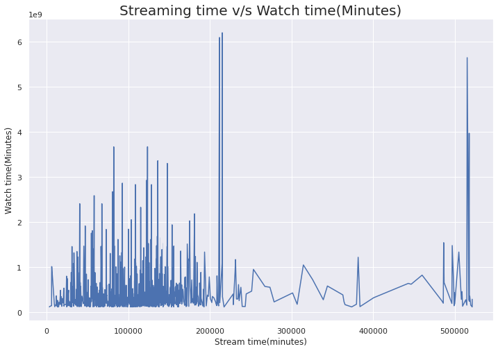

```python
# Comparing streaming time v/s watch time
plt.figure(figsize=(12,8)) #comparing streaming time v/s Watch time(Minutes)
sns.lineplot(streamer['Stream time(minutes)'], streamer['Watch time(Minutes)']);
plt.title('Streaming time v/s Watch time(Minutes)', fontsize = 20);
plt.show();
```

Another interesting thing I found is that longer streaming time does not represent more watch time from viewers. The table above proves this point clearly. The highest peak is the data from streamer xqc, who has the most watch time from viewers. However, his streaming time is only half of the one with the most stream time (RiffTrax). The case of xqc is not accidental. Summit1g, who ranks second in the watch time list, even has less streaming time than xqc. Only the third-ranked Gaules has the high watch time with also high streaming time, while other streamers whose streaming time is as long as Gaules have much lower watch time value.

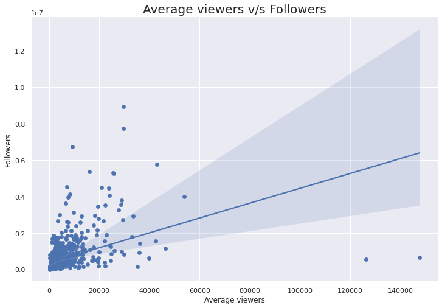

```python
# comparing Average viewers v/s Followers
plt.figure(figsize=(12,8))
sns.scatterplot(streamer['Average viewers'], streamer['Followers']);
sns.regplot(x = 'Average viewers', y = 'Followers', data = streamer);
plt.title('Average viewers v/s Followers', fontsize = 20);
plt.show();
```

```python
# Print the summary of linear regression
x = streamer['Average viewers']
y = streamer['Followers']
result = sm.OLS(y, x).fit()
print(result.summary())
```

```
                                 OLS Regression Results
=======================================================================================
Dep. Variable:              Followers   R-squared (uncentered):                   0.347
Model:                            OLS   Adj. R-squared (uncentered):              0.346
Method:                 Least Squares   F-statistic:                              530.5
Date:                Sat, 17 Dec 2022   Prob (F-statistic):                    1.72e-94
Time:                        00:55:10   Log-Likelihood:                         -15007.
No. Observations:                1000   AIC:                                  3.002e+04
Df Residuals:                     999   BIC:                                  3.002e+04
Df Model:                           1
Covariance Type:            nonrobust
===================================================================================
                      coef    std err          t      P>|t|      [0.025      0.975]
-----------------------------------------------------------------------------------
Average viewers    59.7879      2.596     23.032      0.000      54.694      64.882
==============================================================================
Omnibus:                      380.467   Durbin-Watson:                   1.630
Prob(Omnibus):                  0.000   Jarque-Bera (JB):            76993.008
Skew:                           0.513   Prob(JB):                         0.00
Kurtosis:                      45.974   Cond. No.                         1.00
==============================================================================

Notes:
[1] R² is computed without centering (uncentered) since the model does not contain a constant.
[2] Standard Errors assume that the covariance matrix of the errors is correctly specified.
```

From the scatterplot and positive regression line above, we can conclude that Average viewers and Followers are positively related. This indicates that more average views usually refer to more followers. According to the summary of the linear regression line, we can say one average viewer increase could lead to 59.7879 more followers.

However, we could find two exceptions with the two highest average viewer counts and low follower counts at the bottom right of the scatterplot. Those two channels are dota2ti and dota2ti_ru, which are two official streaming accounts for the video game Dota2. These two accounts only stream when there is an official gaming championship for Dota2. Therefore, in terms of operation strategy, they are not streaming as frequently as other individual streamers, and those large numbers of average viewers will not become followers because most of them are here to watch matches.

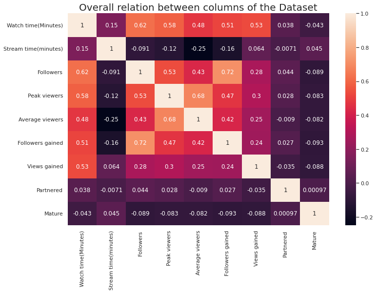

```python
# Plot the head map of correlation between each column
plt.figure(figsize=(12,8))
sns.heatmap(streamer[['Channel', 'Watch time(Minutes)', 'Stream time(minutes)', 'Followers','Peak viewers','Average viewers','Followers gained','Views gained','Partnered','Mature','Language']].corr(), annot = True) #overall correlation between the various columns present in our data
plt.title('Overall relation between columns of the Dataset', fontsize = 20)
plt.show()
```

The heat map shows the overall relation between columns. We can see that Watching time has a middle relation with column followers, peak views, the follower gained, views gained due to R > 0.5, and weak relation with average viewers due to R > 0.25. Column Followers has a strong relation with column followed gained due to R > 0.7, middle relation with column watch time, peak viewers due to R >0.5, and weak relation with column Average viewers, views gained due to R > 0.25.

From the chart, we get to know that the previous graphs of stream time vs. follower and stream time vs. watch time were coming from columns with relatively low correlation values (-0.091 and 0.15), so we couldn't find too much information there. The correlation value of Stream time vs. average viewers (-0.25) is relatively weak, but it indicates the hypothesis we made early was correct. Meanwhile, the -0.091 correlation also shows that there isn't any relation between followers and stream time, which surprises me since most of us will think people with more followers tend to stream more, and people who stream more get more followers. However, it seems like that is not how it works.

We will look at the relation between columns with the highest correlation value next, which are follower vs follower gained (0.72).

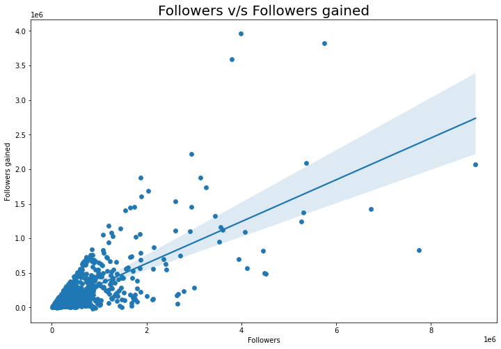

```python
# Comparing followers v/s followers gained
plt.figure(figsize=(12,8)) #comparing streaming time v/s Watch time(Minutes)
sns.scatterplot(streamer['Followers'], streamer['Followers gained']);
sns.regplot(x = 'Followers', y = 'Followers gained', data = streamer);
plt.title('Followers v/s Followers gained', fontsize = 20);
plt.show();
```

```python
# Print summary of linear regression
x = streamer['Followers']
y = streamer['Followers gained']
result = sm.OLS(y, x).fit()
print(result.summary())
```

```
                                 OLS Regression Results
=======================================================================================
Dep. Variable:       Followers gained   R-squared (uncentered):                   0.638
Model:                            OLS   Adj. R-squared (uncentered):              0.638
Method:                 Least Squares   F-statistic:                              1762.
Date:                Sat, 17 Dec 2022   Prob (F-statistic):                   9.26e-223
Time:                        03:46:32   Log-Likelihood:                         -13802.
No. Observations:                1000   AIC:                                  2.761e+04
Df Residuals:                     999   BIC:                                  2.761e+04
Df Model:                           1
Covariance Type:            nonrobust
==============================================================================
                 coef    std err          t      P>|t|      [0.025      0.975]
------------------------------------------------------------------------------
Followers      0.3218      0.008     41.977      0.000       0.307       0.337
==============================================================================
Omnibus:                      771.903   Durbin-Watson:                   1.887
Prob(Omnibus):                  0.000   Jarque-Bera (JB):            51729.304
Skew:                           2.938   Prob(JB):                         0.00
Kurtosis:                      37.742   Cond. No.                         1.00
==============================================================================

Notes:
[1] R² is computed without centering (uncentered) since the model does not contain a constant.
[2] Standard Errors assume that the covariance matrix of the errors is correctly specified.
```

According to the summary of line, coef of 0.3218 implys every 3 followers will refers to 1 gained follower. This represents follower gained are increasing as the total size followers increase. A P-value of 0 also indicate we reject the H0.

## Conclusion

For the general part, among the top 1000 streamers, most were partnered (98%), not streaming mature content (77%), and nearly half of those streamer streaming using the English language(49%). Then for the Individual Streamer Information, the channel with the longest watch time is xqcOW, the channel with the longest stream time is RiffTrax, the channel with the highest peak viewers count is Riot Game, the channel with the highest average viewers count is dota2ti, the channel with the highest followers count is Tfue, the channel with the highest follower gained count is auroplay, the channel with highest views gained count is Fextralife.

For the Analysis part, we get some interesting conclusions. First, Follower and follow gained have strong linear relations. I thought since the total followers grow, the follower gained will tend to decrease compared to the increasing total size. But it shows a positive linear relationship, which means the follower gained will also increase as the total followers increase. My explanation of this was the Twitch platform has an algorithm for doing channel recommendations that when a channel gets more followers, Twitch will promote this channel more vigorously, resulting in more viewers and more new followers. Next, Streaming time actually is negatively proportionally to average viewers (R = -0.25), and Streaming time doesn't relate to views gained(R = 0.064). I believe the part was misunderstood by lots of people, including myself, that streaming more will help the channel gain more viewers and grow bigger. But the data in this dataset shows that more streaming time is related to fewer average viewers, and streaming more doesn't help you get followers or viewers at all.